# TOG RNA-seq Workshop 2021: Part 2

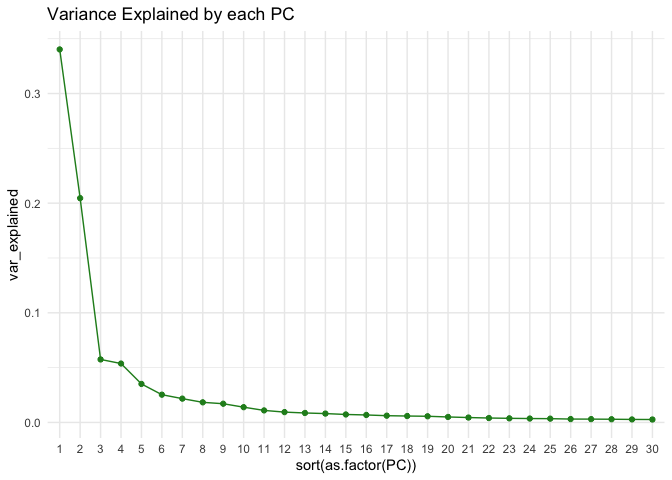

```r
summary %>%
  ggplot(aes(x = sort(as.factor(PC)), y = var_explained))+
  geom_point(colour = "forest green") +
  geom_line(group = "PC", colour = "forest green") +
  theme_minimal() +
  labs(title = "Variance Explained by each PC")
```

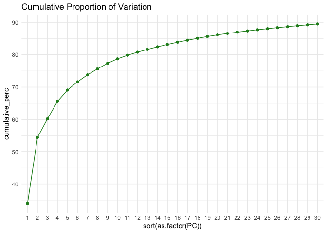

```r
summary %>%
  ggplot(aes(x = sort(as.factor(PC)), y = cumulative_perc))+
  geom_point(colour = "forest green") +
  geom_line(group = "PC", colour = "forest green") +
  theme_minimal() +
  labs(title = "Cumulative Proportion of Variation")
```

```r
#separating the PCA values into its won separate df
scores <- as.data.frame(pca$x)

scores <- scores[c(1:30)]
head(scores)
```

```
##           PC1        PC2        PC3        PC4        PC5        PC6        PC7
## C1  -2.873577  31.513465   4.581241 -34.747719  15.702070 -29.361896   8.508419
## C2   1.069681  21.246050 -10.968403   8.339987  -3.260639 -17.241597  -3.523015
## C3 -21.265732 -16.398176  11.405154 -49.406015 -10.698952  -6.128537  -1.064602
## C4   8.360660  48.599969   9.782527  12.568988   2.640562  -2.135567  -3.014367
## C5 -52.264090   7.886006   7.748767 -25.925634   9.453192  15.599042  -6.826804
## C6  13.613215  29.320890  -6.705883  15.198558  -7.176141   1.188698 -10.093523
##           PC8        PC9       PC10       PC11       PC12        PC13      PC14
## C1 -10.146967 -1.7393485   8.528270 -2.4318774  1.7644941  -5.1124617  1.642345
## C2  -3.660366 -0.8253942  -1.797925 -5.2304072 -0.7391959 -15.2686948 -2.139551
## C3  -5.071375 18.4334570  14.031947 -3.2970120 -6.8373987  -0.4272142  1.500038
## C4  -2.971492 -5.1869985   1.106609  0.6095576 -5.0401862  -6.4507389  2.681354
## C5   2.492451 -2.4695017 -19.801383 -5.0695824 -6.2003436  -2.4090045 11.883342
## C6  -3.208975  2.7844656  -6.127613 -1.0578476  0.4531912 -10.9567302  3.506287
##         PC15      PC16      PC17       PC18      PC19      PC20       PC21
## C1 -8.875898  9.958008 -2.257577  0.0760982 5.0013025 -3.701882  11.100054
## C2 -1.673642 -3.371377  3.338661 -4.5877960 4.8236714 -2.603036   4.839628
## C3  1.668607  8.304741 -5.059460  6.8785575 9.3845361  3.353635   5.716499
## C4 -9.781740  3.395398  2.955598  3.5514763 4.7594520  0.723566   2.178126
## C5  3.812600 10.180299 19.058720 -4.1820518 1.2522601  6.604281 -12.063440
## C6  1.709447 -2.951148  2.932438 -2.6384673 0.2379606 -2.517254   5.712442
##          PC22       PC23       PC24      PC25       PC26       PC27      PC28
## C1 -1.1830862 -4.3701516 -6.0269453  2.487731 -3.9176775  7.2084391 -1.931781
## C2 -0.1437366 -4.0622984  0.6567662  1.469711 -3.0097441  1.4143064 -1.387003
## C3  7.6056574  1.1696635 -1.0229573  1.078533  1.9816533 -0.2157957  1.227088
## C4 -5.2577541  8.6100230  1.0761861 -0.495693  0.2191656 -0.8076055  2.522992
## C5  4.2031459  4.3432118  3.7112434  3.547634  3.0213863  4.0804927 -4.757769
## C6  2.2821878 -0.9523062 -1.6960234  2.700263  3.7529861  2.8236221 -2.476955
##          PC29        PC30
## C1  7.1364450 -1.27354936
## C2 -2.0213152 -1.19972570
## C3  7.3628155 12.38335042
## C4 -3.9418235 -0.03496177
## C5  0.7855329  0.31440811
## C6  0.1467464  0.12057683
```

```r
#making a metadata df containing all sample information data
mDat <- cbind(pDat, scores)
```

Now that we have our PC scores, we’ll estimate which of our variables are the ones driving that variation in our data

```r
#remotes::install_github("wvictor14/plomics")
library(plomics)

#here, we'll select the Pvalue metric
variable_variance <- lmmatrix(dep = scores, ind = pDat[c(2:15)], metric = "Pvalue")

head(variable_variance)
```

```
##                         PC1          PC2          PC3          PC4         PC5
## Age            4.433720e-01 1.024292e-03 5.357586e-01 0.1227241839 0.530243367
## Sex            2.270582e-01 2.730491e-01 4.905150e-01 0.9222153751 0.985665262
## COVID          3.356380e-04 3.558523e-03 3.231238e-11 0.2342246582 0.005592154
## ICU            8.607671e-04 1.152275e-10 1.203749e-01 0.0004498275 0.761884831
## APACHEII_Score 9.648283e-06 4.796524e-11 6.234301e-03 0.0039225543 0.022536445
## Charlson_Score 4.551605e-01 1.596603e-03 3.119950e-01 0.4360322298 0.847497524
##                        PC6        PC7       PC8        PC9      PC10       PC11
## Age            0.003551443 0.04887319 0.9698820 0.08404132 0.4838427 0.14276659
## Sex            0.924984016 0.74093414 0.6743761 0.53969685 0.5688295 0.21571274
## COVID          0.765978287 0.02029783 0.1465711 0.82483687 0.5066316 0.83510449
## ICU            0.698404893 0.19821494 0.6957646 0.92452028 0.9779782 0.50625488
## APACHEII_Score 0.456567963 0.51758869 0.2700249 0.37744914 0.6434340 0.47439984
## Charlson_Score 0.249114900 0.10373783 0.3765287 0.69639356 0.3802474 0.02343673
##                      PC12       PC13      PC14      PC15       PC16      PC17
## Age            0.88361422 0.29556981 0.1560049 0.6758504 0.94884057 0.6832243
## Sex            0.12288159 0.17095735 0.2707008 0.7513489 0.08798836 0.3760878
## COVID          0.28871134 0.36779251 0.8489379 0.2753187 0.89386734 0.4998182
## ICU            0.08508769 0.07605797 0.4620665 0.3548583 0.90081795 0.1395691
## APACHEII_Score 0.47503481 0.03731661 0.6887634 0.6241562 0.96863246 0.3662505
## Charlson_Score 0.06465515 0.17139990 0.8719106 0.5129812 0.90253659 0.5135770
##                      PC18        PC19      PC20       PC21      PC22      PC23
## Age            0.88442521 0.005217742 0.9607615 0.37280299 0.5185930 0.3420459
## Sex            0.43156896 0.142272226 0.4658982 0.35591767 0.7702244 0.5003367
## COVID          0.25625700 0.532989041 0.3405511 0.02320487 0.6135451 0.3112817
## ICU            0.01080291 0.583716805 0.7760423 0.79522088 0.3668543 0.2460771
## APACHEII_Score 0.09355615 0.961482917 0.7125361 0.95046979 0.9949991 0.9708908
## Charlson_Score 0.43556492 0.269060667 0.4242116 0.07719944 0.3677115 0.1525067
##                      PC24       PC25       PC26      PC27       PC28
## Age            0.23333502 0.52453069 0.71000558 0.5339782 0.45641686
## Sex            0.92204393 0.57985293 0.01979339 0.3029324 0.02703745
## COVID          0.51166564 0.38139380 0.79538660 0.3603583 0.81197760
## ICU            0.06641195 0.90489350 0.88716159 0.5934191 0.73924939
## APACHEII_Score 0.15238958 0.53764391 0.66193829 0.8974279 0.50100394
## Charlson_Score 0.11556830 0.09411374 0.38307618 0.2623510 0.02145716
##                        PC29      PC30
## Age            0.0001336431 0.1245905
## Sex            0.1733599130 0.9956886
## COVID          0.8094699294 0.7442335
## ICU            0.5637311577 0.7969355
## APACHEII_Score 0.3283939438 0.4591115
## Charlson_Score 0.0298356039 0.7890196
```

```r
vv_plot <- variable_variance %>%
  as.data.frame()
vv_plot <- as.data.frame(t(vv_plot))
vv_plot <- vv_plot %>%
  mutate(Principle_Component = 1:30) %>%
  dplyr::select(Principle_Component, everything())
head(vv_plot)
```

```
##     Principle_Component         Age       Sex        COVID          ICU
## PC1                   1 0.443372048 0.2270582 3.356380e-04 8.607671e-04
## PC2                   2 0.001024292 0.2730491 3.558523e-03 1.152275e-10
## PC3                   3 0.535758592 0.4905150 3.231238e-11 1.203749e-01
## PC4                   4 0.122724184 0.9222154 2.342247e-01 4.498275e-04
## PC5                   5 0.530243367 0.9856653 5.592154e-03 7.618848e-01
## PC6                   6 0.003551443 0.9249840 7.659783e-01 6.984049e-01
##     APACHEII_Score Charlson_Score Mechanical_Ventilation Ventilator_free_days
## PC1   9.648283e-06    0.455160547           2.035603e-07         5.407286e-03
## PC2   4.796524e-11    0.001596603           3.001057e-06         6.660971e-05
## PC3   6.234301e-03    0.311995034           3.438765e-02         1.140585e-04
## PC4   3.922554e-03    0.436032230           1.228092e-02         4.958919e-01
## PC5   2.253645e-02    0.847497524           2.315671e-01         1.297751e-01
## PC6   4.565680e-01    0.249114900           2.960095e-01         3.598802e-01
##     Hospital_free_days_post_45_days Ferritin_ng.ml     CRP_mg.l
## PC1                    2.161055e-03   5.641500e-02 0.0013990643
## PC2                    9.070318e-09   3.268577e-01 0.0870827222
## PC3                    1.276553e-06   7.301131e-06 0.0000294515
## PC4                    3.399023e-01   5.905019e-01 0.7613512673
## PC5                    3.001829e-01   8.238546e-01 0.7530516400
## PC6                    1.702699e-01   7.176295e-01 0.8095881925
##     Procalcitonin_ng.ml Lactate_mmol.l Fibrinogen_mg.dL
## PC1         0.466435480    0.359643697      0.084735902
## PC2         0.407907372    0.006193814      0.900148170
## PC3         0.029758491    0.095157140      0.002538692
## PC4         0.410411302    0.286958286      0.818851094
## PC5         0.008701715    0.821823536      0.336487280
## PC6         0.665651463    0.432498676      0.149312722
```

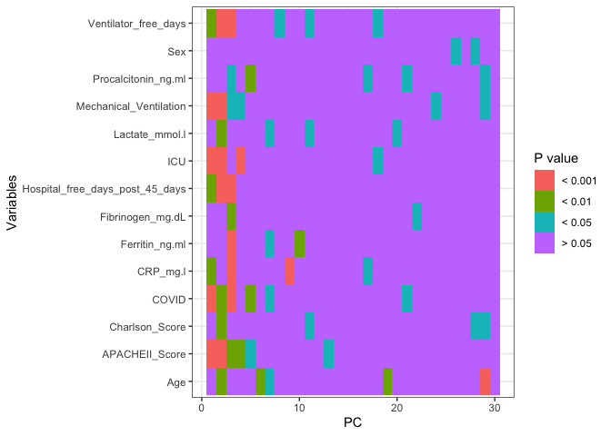

```r
vv_plot <- vv_plot %>%
  pivot_longer(cols = -c(Principle_Component), names_to = "variables", values_to = "pval")
vv_plot <- vv_plot %>%
  mutate(pval_cat = case_when(
    pval > 0.05  ~ "> 0.05",
    pval < 0.05 & pval > 0.01 ~ "< 0.05",
    pval < 0.01 & pval > 0.001 ~ "< 0.01",
    pval < 0.001 ~ "< 0.001"
  ))

vv_plot %>%
  ggplot(aes(x = Principle_Component, y = variables, fill = pval_cat)) +
  geom_tile() +
  theme_bw() +
  labs(x = "PC", y = "Variables" , fill = "P value")
```

```r
vv_colpal <- c("< 0.001" = "#ef6a4c", "< 0.01" = "#f59e72", "< 0.05" = "#fde0c5", "> 0.05" = "white")
vv_plot$Principle_Component <- as.factor(vv_plot$Principle_Component)

g3 <- vv_plot %>%
  ggplot(aes(x = Principle_Component, y = variables, fill = pval_cat)) +
  geom_tile(col = "lightgrey") +
  theme_bw() +
  scale_x_discrete(expand = c(0, 0)) +
  scale_y_discrete(expand = c(0, 0)) +
  scale_fill_manual(values = vv_colpal) +
  coord_fixed() +
  # theme(legend.position = "bottom") +
  labs(x = "PC", y = "Variables" , fill = "P value")

# ASSIGNMENT 1: Repeat the lmmatrix function, but this time with using the Rsqaured value. Store it as a separate variable, and plot both the pval and rsquared plots one below each other.
# Instead of using `scale_fill_manual` for the plot, use `scale_fill_gradient(low = "", high = "#")`

rsq <- lmmatrix(dep = scores, ind = pDat[c(2:15)], metric = "Rsquared")

rsq <- rsq %>%
  as.data.frame()

rsq <- as.data.frame(t(rsq))

rsq <- rsq %>%
  mutate(Principle_Component = 1:30) %>%
  dplyr::select(Principle_Component, everything())

head(rsq)
```

```
##     Principle_Component         Age          Sex       COVID          ICU
## PC1                   1 0.004746062 0.0238182452 0.098889121 0.0859946047
## PC2                   2 0.083606593 0.0208861737 0.066481503 0.2856273580
## PC3                   3 0.003100076 0.0115152891 0.299867096 0.0193440583
## PC4                   4 0.019103990 0.0013158244 0.011392135 0.0948872854
## PC5                   5 0.003184566 0.0002347444 0.060269454 0.0007431426
## PC6                   6 0.066508892 0.0012671448 0.000717059 0.0012149315
##     APACHEII_Score Charlson_Score Mechanical_Ventilation Ventilator_free_days
## PC1     0.14660374   0.0045061211             0.19635489          0.060731067
## PC2     0.29547182   0.0775061355             0.16191424          0.120830111
## PC3     0.05877739   0.0082427650             0.03558802          0.113565869
## PC4     0.06514221   0.0049004727             0.04949967          0.003747719
## PC5     0.04126041   0.0002994187             0.01152171          0.018412669
## PC6     0.00447812   0.0106973907             0.00880372          0.006764889
##     Hospital_free_days_post_45_days Ferritin_ng.ml     CRP_mg.l
## PC1                     0.073342365   0.0290411798 0.0793220901
## PC2                     0.234656728   0.0077535666 0.0234252650
## PC3                     0.172984201   0.1502774278 0.1317808459
## PC4                     0.007347690   0.0023418570 0.0007465799
## PC5                     0.008653592   0.0004011011 0.0008011664
## PC6                     0.015111705   0.0010583402 0.0004700105
##     Procalcitonin_ng.ml Lactate_mmol.l Fibrinogen_mg.dL
## PC1         0.004285549   0.0067715297     0.0237743019
## PC2         0.005530277   0.0588667977     0.0001274707
## PC3         0.037521591   0.0222970352     0.0711267185
## PC4         0.005471633   0.0091387516     0.0004246148
## PC5         0.054207104   0.0004105611     0.0074519270
## PC6         0.001510836   0.0049762262     0.0166949341
```

```r
rsq <- rsq %>%
  pivot_longer(cols = -c(Principle_Component), names_to = "variables", values_to = "rsq")

rsq$Principle_Component <- as.factor(rsq$Principle_Component)

str(rsq)
```

```
## tibble [420 × 3] (S3: tbl_df/tbl/data.frame)
##  $ Principle_Component: Factor w/ 30 levels "1","2","3","4",..: 1 1 1 1 1 1 1 1 1 1 ...
##  $ variables          : chr [1:420] "Age" "Sex" "COVID" "ICU" ...
##  $ rsq                : num [1:420] 0.00475 0.02382 0.09889 0.08599 0.1466 ...
```

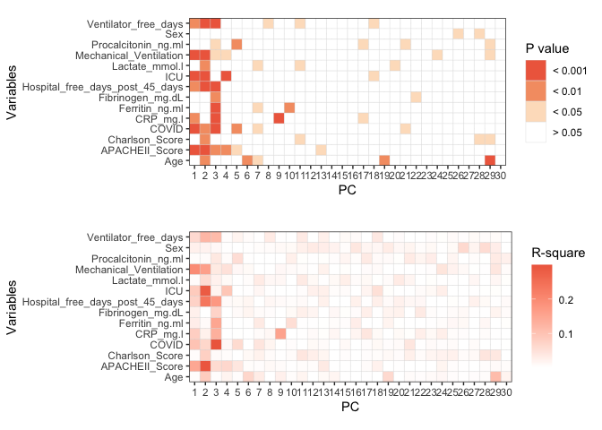

```r
g4 <- rsq %>%
  ggplot(aes(x = Principle_Component, y = variables, fill = rsq)) +
  geom_tile(col = "lightgrey") +
  theme_bw() +
  scale_x_discrete(expand = c(0, 0)) +
  scale_y_discrete(expand = c(0, 0)) +
  scale_fill_gradient(low = "white", high = "#ef6a4c") +
  coord_fixed() +
  # theme(legend.position = "bottom") +
  labs(x = "PC", y = "Variables" , fill = "R-square")

ggarrange(g3, g4, ncol = 1, nrow = 2)
```

We’ll now plot the first 2 PCs with the variables that seem to be contributing to the most variance in the data.

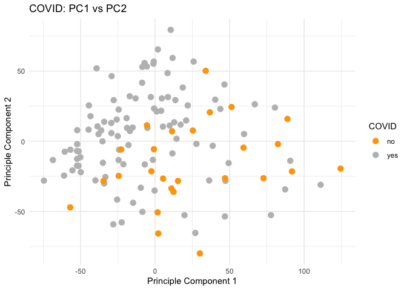

```r
mDat %>%
  ggplot(aes(x = PC1, y = PC2, colour = COVID)) +
  geom_point(size = 3) +
  # coord_cartesian(ylim = c(-130, 130), xlim = c(-130, 130)) +
  labs( x = "Principle Component 1", y = "Principle Component 2", title = "COVID: PC1 vs PC2") +
  scale_colour_manual(values = c("orange", "gray")) +
  theme_minimal()
```

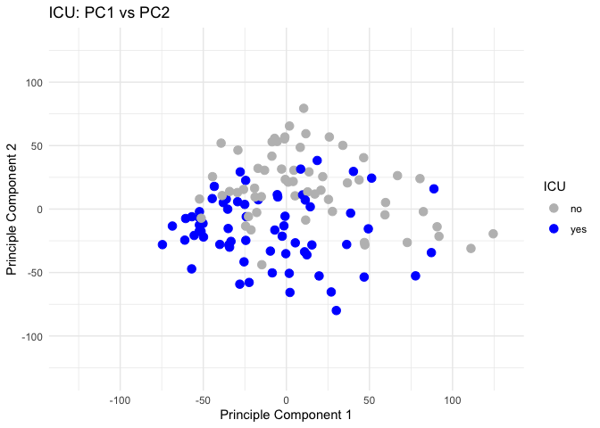

```r
mDat %>%
  ggplot(aes(x = PC1, y = PC2, colour = ICU)) +
  geom_point(size = 3) +
  coord_cartesian(ylim = c(-130, 130), xlim = c(-130, 130)) +
  labs( x = "Principle Component 1", y = "Principle Component 2", title = "ICU: PC1 vs PC2") +
  scale_colour_manual(values = c("grey", "blue")) +
  theme_minimal()
```

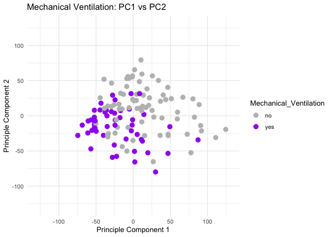

```r
mDat %>%
  ggplot(aes(x = PC1, y = PC2, colour = Mechanical_Ventilation)) +
  geom_point(size = 3) +
  coord_cartesian(ylim = c(-130, 130), xlim = c(-130, 130)) +
  labs( x = "Principle Component 1", y = "Principle Component 2", title = "Mechanical Ventilation: PC1 vs PC2") +
  scale_colour_manual(values = c("grey", "purple")) +
  theme_minimal()
```

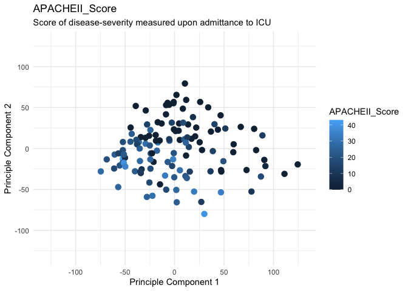

```r
mDat %>%
  # mutate(AP_score = case_when(
  #   APACHEII_Score <= 10 ~ "less_than_10",
  #   between(APACHEII_Score, 11, 20) ~ "eleven_to_20",
  #   between(APACHEII_Score, 21, 30) ~ "twentyone_to_30",
  #   between(APACHEII_Score, 31, 40) ~ "thirtyone_to_40",
  #   APACHEII_Score > 40 ~ "more_than_40")) %>%
  ggplot(aes(x = PC1, y = PC2, colour = APACHEII_Score)) +
  geom_point(size = 3) +
  coord_cartesian(ylim = c(-130, 130), xlim = c(-130, 130)) +
  labs( x = "Principle Component 1", y = "Principle Component 2", title = "APACHEII_Score", subtitle = "Score of disease-severity measured upon admittance to ICU") +
  theme_minimal()
```

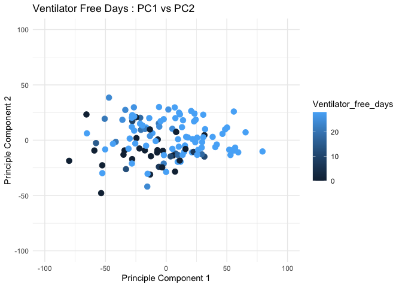

```r
#EXTRA - COMPARE PC2 and PC3
#PC2-3

mDat %>%
  ggplot(aes(x = PC2, y = PC3, colour = Ventilator_free_days)) +
  geom_point(size = 3) +
  coord_cartesian(ylim = c(-100, 100), xlim = c(-100, 100)) +
  labs( x = "Principle Component 1", y = "Principle Component 2", title = "Ventilator Free Days : PC1 vs PC2") +
  #scale_colour_manual(values = c("grey", "purple")) +
  theme_minimal()
```

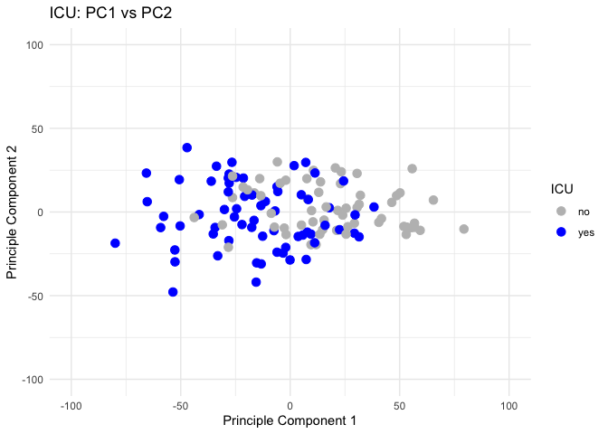

```r
mDat %>%
  ggplot(aes(x = PC2, y = PC3, colour = ICU)) +
  geom_point(size = 3) +
  coord_cartesian(ylim = c(-100, 100), xlim = c(-100, 100)) +
  labs( x = "Principle Component 1", y = "Principle Component 2", title = "ICU: PC1 vs PC2") +
  scale_colour_manual(values = c("grey", "blue")) +
  theme_minimal()
```

### 7.0 Differential Expression Analysis

Okay, now moving into DE analysis: we’re going to use the limma package, rather than the more popular DESeq2 or edgeR packages. There’s broadly 3 steps to pulling out DE genes:

1. Specifying your variables of interest to generate a model in the form of a matrix
2. Fitting our data to that model
3. Applying Bayesian statistics to the results of our model

```r
library(limma)

mm_covid <- model.matrix(~COVID, pDat)
#always better to use an intercept, as the starting value is not forced to zero

head(mm_covid)
```

```
##    (Intercept) COVIDyes
## C1           1        1
## C2           1        1
## C3           1        1
## C4           1        1
## C5           1        1
## C6           1        1
```

```r
all(rownames(pDat) == colnames(eNorm))
```

```
## [1] TRUE
```

```r
efit_COVID <- lmFit(eNorm, mm_covid)

efit_COVID <- efit_COVID %>%
  eBayes()

#"BH", "BY" and "holm"
topTable(efit_COVID, coef = "COVIDyes", adjust.method = "fdr", p.value = 0.05)
```

```
##                logFC    AveExpr         t      P.Value    adj.P.Val        B
## GBGT1     -14.346965  13.119938 -8.608852 2.704926e-14 3.208042e-10 21.74699
## MCM6       13.006445  20.821294  8.119125 3.863965e-13 1.759204e-09 19.24480
## SLC12A9   -95.036340 100.648629 -8.092907 4.449926e-13 1.759204e-09 19.11189
## SLC15A3   -59.232204  68.814556 -7.998129 7.405414e-13 2.195705e-09 18.63245
## MAPK8IP3  -18.433847  29.398845 -7.874219 1.437384e-12 3.409474e-09 18.00811
## CDC7        3.365151   5.656738  7.711515 3.417089e-12 6.754446e-09 17.19281
## AIF1     -323.686454 472.519567 -7.566778 7.346232e-12 1.244662e-08 16.47216
## CLSPN       2.952676   4.133007  7.437656 1.448122e-11 2.146841e-08 15.83317
## PITPNM1   -16.397367  24.699942 -7.409046 1.682170e-11 2.216727e-08 15.69211
## TWF2      -84.289346 100.564424 -7.327147 2.580083e-11 3.059979e-08 15.28940
```

```r
topTable(efit_COVID, coef = "COVIDyes", adjust.method = "fdr", p.value = 0.05)
```

```
##                logFC    AveExpr         t      P.Value    adj.P.Val        B
## GBGT1     -14.346965  13.119938 -8.608852 2.704926e-14 3.208042e-10 21.74699
## MCM6       13.006445  20.821294  8.119125 3.863965e-13 1.759204e-09 19.24480
## SLC12A9   -95.036340 100.648629 -8.092907 4.449926e-13 1.759204e-09 19.11189
## SLC15A3   -59.232204  68.814556 -7.998129 7.405414e-13 2.195705e-09 18.63245
## MAPK8IP3  -18.433847  29.398845 -7.874219 1.437384e-12 3.409474e-09 18.00811
## CDC7        3.365151   5.656738  7.711515 3.417089e-12 6.754446e-09 17.19281
## AIF1     -323.686454 472.519567 -7.566778 7.346232e-12 1.244662e-08 16.47216
## CLSPN       2.952676   4.133007  7.437656 1.448122e-11 2.146841e-08 15.83317
## PITPNM1   -16.397367  24.699942 -7.409046 1.682170e-11 2.216727e-08 15.69211
## TWF2      -84.289346 100.564424 -7.327147 2.580083e-11 3.059979e-08 15.28940
```

```r
topTable(efit_COVID, coef = "COVIDyes", adjust.method = "fdr", p.value = 0.05, sort.by = "p")
```

```
##                logFC    AveExpr         t      P.Value    adj.P.Val        B
## GBGT1     -14.346965  13.119938 -8.608852 2.704926e-14 3.208042e-10 21.74699
## MCM6       13.006445  20.821294  8.119125 3.863965e-13 1.759204e-09 19.24480
## SLC12A9   -95.036340 100.648629 -8.092907 4.449926e-13 1.759204e-09 19.11189
## SLC15A3   -59.232204  68.814556 -7.998129 7.405414e-13 2.195705e-09 18.63245
## MAPK8IP3  -18.433847  29.398845 -7.874219 1.437384e-12 3.409474e-09 18.00811
## CDC7        3.365151   5.656738  7.711515 3.417089e-12 6.754446e-09 17.19281
## AIF1     -323.686454 472.519567 -7.566778 7.346232e-12 1.244662e-08 16.47216
## CLSPN       2.952676   4.133007  7.437656 1.448122e-11 2.146841e-08 15.83317
## PITPNM1   -16.397367  24.699942 -7.409046 1.682170e-11 2.216727e-08 15.69211
## TWF2      -84.289346 100.564424 -7.327147 2.580083e-11 3.059979e-08 15.28940
```

```r
topTable(efit_COVID, coef = "COVIDyes", adjust.method = "fdr", p.value = 0.05, sort.by = "logFC")
```

```
##               logFC   AveExpr         t      P.Value    adj.P.Val           B
## S100A9   -10554.113 22372.842 -2.567381 1.142823e-02 2.912609e-02 -3.14921169
## HBA2      -4627.381  2670.516 -5.072714 1.385177e-06 3.487942e-05  5.06699674
## ACTB      -4416.516  7242.785 -6.023213 1.782930e-08 1.639190e-06  9.14052918
## FTL       -4187.909  6897.358 -5.544648 1.679337e-07 7.572980e-06  7.03827981
## IFITM2    -2848.844  5357.986 -3.659910 3.710775e-04 1.980639e-03 -0.09398016
## RNA28SN1  -2740.657  2785.014 -5.705683 7.982667e-08 4.733722e-06  7.73475274
## RNA28SN4  -2351.735  1437.686 -7.147384 6.556764e-11 4.860201e-08 14.41135701
## EEF1A1    -2146.417  8071.037 -3.468840 7.182910e-04 3.236676e-03 -0.69295220
## FCGR3B     2140.546  6069.773  2.383893 1.863926e-02 4.307319e-02 -3.56958200
## HBA1      -2103.973  1667.291 -3.847665 1.893569e-04 1.225359e-03  0.51944745
```

```r
#google S100A9, GBGT1, and COVID - what do we find?
```

```r
mm_age <- model.matrix(~COVID + Age, pDat)

#We'll first, however, get some statistics on the quality of our model with including age
mm_age <- as.data.frame(mm_age)

#logistic requires categorical to be either yes or no
model1 <- glm(COVIDyes ~ Age, data = mm_age, family = binomial)
summary(model1)
```

```
##
## Call:
## glm(formula = COVIDyes ~ Age, family = binomial, data = mm_age)
##
## Deviance Residuals:
##     Min       1Q   Median       3Q      Max
## -1.9352   0.5739   0.6543   0.7122   0.7818
##
## Coefficients:
##             Estimate Std. Error z value Pr(>|z|)
## (Intercept)  2.08533    0.88314   2.361   0.0182 *
## Age         -0.01187    0.01353  -0.877   0.3804
## ---
## Signif. codes:  0 '***' 0.001 '**' 0.01 '*' 0.05 '.' 0.1 ' ' 1
##
## (Dispersion parameter for binomial family taken to be 1)
##
##     Null deviance: 128.29  on 125  degrees of freedom
## Residual deviance: 127.49  on 124  degrees of freedom
## AIC: 131.49
##
## Number of Fisher Scoring iterations: 4
```

```r
#Here the summary shows that age does not seem to strongly correlate with COVID status, and so hence we would not expect a major change in our results on including it in our model (and so hence, we should not). However, just to test that, let's add it to out model and check the resutls.

mm_age <- model.matrix(~COVID + Age, pDat)

efit_age <- lmFit(eNorm, mm_age) %>%
  eBayes()

topTable(efit_age, coef = "COVIDyes", adjust.method = "fdr", p.value = 0.05, sort.by = "logFC")
```

```
##               logFC   AveExpr         t      P.Value    adj.P.Val          B
## S100A9   -10160.956 22372.842 -2.468919 1.491768e-02 3.595278e-02 -3.3784598
## HBA2      -4648.774  2670.516 -5.061858 1.465260e-06 3.794319e-05  5.0153718
## ACTB      -4316.973  7242.785 -5.916899 3.003894e-08 2.698953e-06  8.6518054
## FTL       -4089.673  6897.358 -5.436198 2.784468e-07 1.182517e-05  6.5659556
## RNA28SN1  -2764.601  2785.014 -5.723978 7.430527e-08 5.123607e-06  7.8026755
## IFITM2    -2700.867  5357.986 -3.528938 5.866230e-04 2.833951e-03 -0.5090658
## RNA28SN4  -2357.059  1437.686 -7.114010 8.004557e-11 6.328936e-08 14.2240520
## EEF1A1    -2349.765  8071.037 -4.066164 8.445041e-05 6.874275e-04  1.2600294
## FCGR3B     2193.313  6069.773  2.430801 1.650034e-02 3.894029e-02 -3.4649414
## HBA1      -2114.040  1667.291 -3.839525 1.957299e-04 1.271976e-03  0.4898601
```

```r
topTable(efit_age, coef = "COVIDyes", adjust.method = "fdr", p.value = 0.05, sort.by = "p")
```

```
##                logFC    AveExpr         t      P.Value    adj.P.Val        B
## GBGT1     -14.046860  13.119938 -8.550910 3.893914e-14 4.618182e-10 21.40403
## MCM6       12.757246  20.821294  8.034319 6.344663e-13 3.003183e-09 18.77807
## SLC12A9   -93.350898 100.648629 -8.000681 7.596584e-13 3.003183e-09 18.60857
## SLC15A3   -58.215586  68.814556 -7.902345 1.284422e-12 3.808311e-09 18.11420
## MAPK8IP3  -18.489458  29.398845 -7.844907 1.743990e-12 4.136744e-09 17.82627
## CDC7        3.324990   5.656738  7.608243 6.104652e-12 1.206686e-08 16.64678
## AIF1     -321.225164 472.519567 -7.472091 1.247953e-11 2.114389e-08 15.97360
## PITPNM1   -16.437456  24.699942 -7.376130 2.060166e-11 2.972291e-08 15.50168
## TTC9      -24.915019  19.432974 -7.350907 2.349422e-11 2.972291e-08 15.37799
## CLSPN       2.923208   4.133007  7.338497 2.506148e-11 2.972291e-08 15.31720
```